# Reproducible research week 2 assignment

## Load the data

Set working directory and download and unzip the file from the internet.

```r
# Set working directory
setwd("~/Documents/BGS_admin/Training/Data_science/Module_5_Reproducible Research/Week_2_not_completed/Assignment")

# Download the file from the internet
download.file("https://d396qusza40orc.cloudfront.net/repdata%2Fdata%2Factivity.zip", destfile = "activity.zip", mode="wb")

# Unzip the file
unzip("activity.zip")
Steps <- read.csv("activity.csv", header = TRUE)
```

## Summarise the data

Summarise the step data.

```r
# Summarise the data
head(Steps)
```

|  | steps | date | interval |
| --- | --- | --- | --- |
| 1 | NA | 2012-10-01 | 0 |
| 2 | NA | 2012-10-01 | 5 |
| 3 | NA | 2012-10-01 | 10 |
| 4 | NA | 2012-10-01 | 15 |
| 5 | NA | 2012-10-01 | 20 |
| 6 | NA | 2012-10-01 | 25 |

```r
summary(Steps)
```

```
##      steps                date          interval
##  Min.   :  0.00   2012-10-01:  288   Min.   :   0.0
##  1st Qu.:  0.00   2012-10-02:  288   1st Qu.: 588.8
##  Median :  0.00   2012-10-03:  288   Median :1177.5
##  Mean   : 37.38   2012-10-04:  288   Mean   :1177.5
##  3rd Qu.: 12.00   2012-10-05:  288   3rd Qu.:1766.2
##  Max.   :806.00   2012-10-06:  288   Max.   :2355.0
##  NA's   :2304     (Other)   :15840
```

```r
str(Steps)
```

```
## 'data.frame':    17568 obs. of  3 variables:
##  $ steps   : int  NA NA NA NA NA NA NA NA NA NA ...
##  $ date    : Factor w/ 61 levels "2012-10-01","2012-10-02",..: 1 1 1 1 1 1 1 1 1 1 ...
##  $ interval: int  0 5 10 15 20 25 30 35 40 45 ...
```

## What is mean total number of steps taken per day?

The total number of steps taken per day is shown below.

```r
# Aggregate the steps taken by day and then sum to calculate the total steps taken per day
Steps_Day <- aggregate(Steps$steps, by=list(Steps$date), sum)
colnames(Steps_Day) <- c("Day", "Total_steps")

# Display the result
head(Steps_Day)
```

|  | Day | Total_steps |
| --- | --- | --- |
| 1 | 2012-10-01 | NA |
| 2 | 2012-10-02 | 126 |
| 3 | 2012-10-03 | 11352 |
| 4 | 2012-10-04 | 12116 |
| 5 | 2012-10-05 | 13294 |
| 6 | 2012-10-06 | 15420 |

Figure 1 shows a histogram of the total steps taken per day.

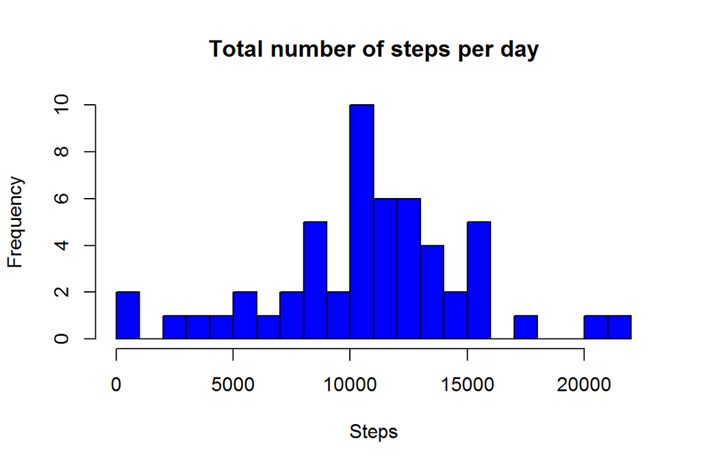

```r
hist(Steps_Day$Total_steps, xlab = "Steps", breaks = 20, main="Total number of steps per day", col = c("blue"))
```

The mean and median of the total number of steps taken per day is shown below.

```r
# Calculate the mean
mean(Steps_Day$Total_steps, na.rm=TRUE)
```

```
## [1] 10766.19
```

```r
# Calculate the median
median(Steps_Day$Total_steps, na.rm=TRUE)
```

```
## [1] 10765
```

## What is the average daily activity pattern?

Figure 2 shows a time series plot of the average number of steps across all days plotted against the whole day split into 5 minute intervals.

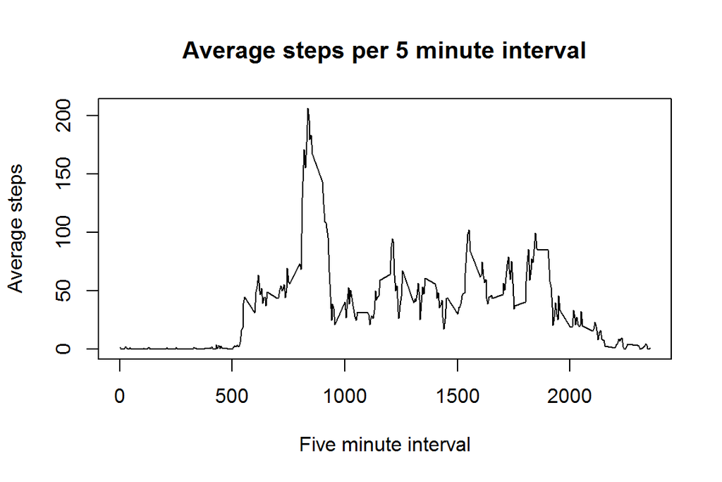

```r
# Create a new matrix with mean values for each 5 minute interval, in order to do so remove any 5 minute interval without data.
NA_ind <- is.na(Steps$steps)
Steps_nNA <- Steps[!NA_ind,]
Steps_int <- aggregate(Steps_nNA$steps, by=list(Steps_nNA$interval), mean)
colnames(Steps_int) <- c("Interval", "Steps")

# Plot the average number of steps across the days per 5 minute interval
plot(Steps_int$Interval, Steps_int$Steps, type = "l", xlab = "Five minute interval", ylab = "Average steps", main="Average steps per 5 minute interval")
```

The 5 minute interval during the day, which on average, has the maximum number of steps is shown below.

```r
Steps_int_max <- Steps_int[which.max(Steps_int$Steps),]
Steps_int_max
```

|  | Interval | Steps |
| --- | --- | --- |
| 104 | 835 | 206.1698 |

## Imputing missing values

The number of missing values from the database are shown below.

```r
No_vals <- sum(NA_ind)
No_vals
```

```
## [1] 2304
```

The missing values are replaced in the original dataset with the mean of each 5 minute interval calculated using the remainder of the dataset.

```r
# Construct a function to replace the missing values
replace_with_mean <- function(num) replace(num, is.na(num), mean(num, na.rm = TRUE))

#Replace the missing values
library(dplyr)
Steps_replaced <- (Steps %>% group_by(interval) %>% mutate(steps = replace_with_mean(steps)))

# Display the new dataset
head(Steps_replaced)
```

| steps | date | interval |
| --- | --- | --- |
| 1.7169811 | 2012-10-01 | 0 |
| 0.3396226 | 2012-10-01 | 5 |
| 0.1320755 | 2012-10-01 | 10 |
| 0.1509434 | 2012-10-01 | 15 |
| 0.0754717 | 2012-10-01 | 20 |
| 2.0943396 | 2012-10-01 | 25 |

```r
# Check that no missing values remain.
sum(is.na(Steps_replaced))
```

```
## [1] 0
```

The new dataset is summarised below.

```r
# Convert the new dataset to a dataframe
Steps_replaced <- as.data.frame(Steps_replaced)

# Summarise the new dataframe
head(Steps_replaced)
```

|  | steps | date | interval |
| --- | --- | --- | --- |
| 1 | 1.7169811 | 2012-10-01 | 0 |
| 2 | 0.3396226 | 2012-10-01 | 5 |
| 3 | 0.1320755 | 2012-10-01 | 10 |
| 4 | 0.1509434 | 2012-10-01 | 15 |
| 5 | 0.0754717 | 2012-10-01 | 20 |
| 6 | 2.0943396 | 2012-10-01 | 25 |

```r
summary(Steps_replaced)
```

```
##      steps                date          interval
##  Min.   :  0.00   2012-10-01:  288   Min.   :   0.0
##  1st Qu.:  0.00   2012-10-02:  288   1st Qu.: 588.8
##  Median :  0.00   2012-10-03:  288   Median :1177.5
##  Mean   : 37.38   2012-10-04:  288   Mean   :1177.5
##  3rd Qu.: 27.00   2012-10-05:  288   3rd Qu.:1766.2
##  Max.   :806.00   2012-10-06:  288   Max.   :2355.0
##                   (Other)   :15840
```

```r
str(Steps_replaced)
```

```
## 'data.frame':    17568 obs. of  3 variables:
##  $ steps   : num  1.717 0.3396 0.1321 0.1509 0.0755 ...
##  $ date    : Factor w/ 61 levels "2012-10-01","2012-10-02",..: 1 1 1 1 1 1 1 1 1 1 ...
##  $ interval: int  0 5 10 15 20 25 30 35 40 45 ...
```

The mean and median of the total number of steps taken per day is shown below.

```r
# Aggregate the steps taken by day and then sum to calculate the total steps taken per day
Steps_Day_rep <- aggregate(Steps_replaced$steps, by=list(Steps_replaced$date), sum)
colnames(Steps_Day_rep) <- c("Day", "Total_steps")

# Calculate the mean
mean(Steps_Day_rep$Total_steps)
```

```
## [1] 10766.19
```

```r
# Calculate the median
median(Steps_Day_rep$Total_steps)
```

```
## [1] 10766.19
```

Replacing the missing values has increased the median by 1.19, but the mean remains the same.

Figure 3 shows a histogram of the total steps taken per day but using the new dataset (red) compared to the old dataset (blue).

```r
par(1,2)
```

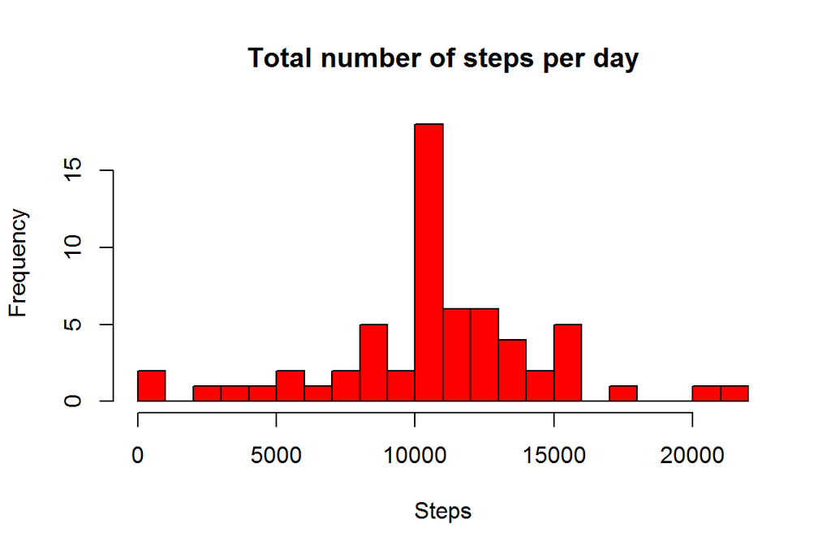

```r
hist(Steps_Day_rep$Total_steps, xlab = "Steps", breaks = 20, main="Total number of steps per day", col = c("red"))
```

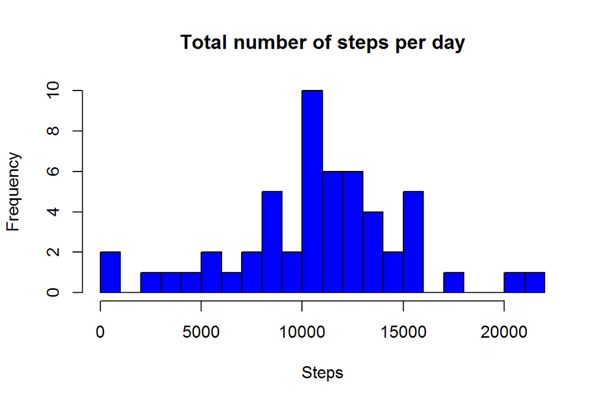

```r
hist(Steps_Day$Total_steps, xlab = "Steps", breaks = 20, main="Total number of steps per day", col = c("blue"))
```

## Are there differences in activity patterns between weekdays and weekends?

The new dataset is split up into weekends and weekdays and activity levels are compared in Figure 4.

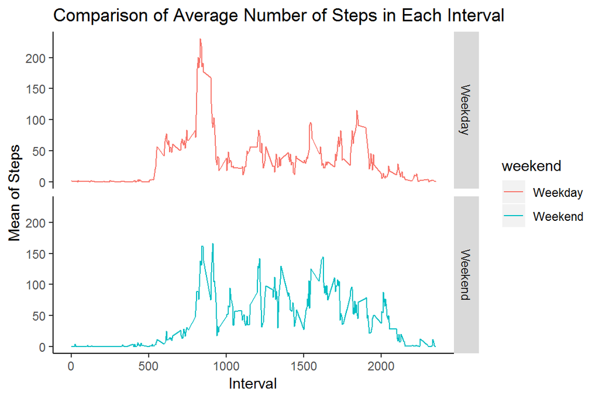

```r
# Create new dataframe wth weekday and weekend variables
Steps_replaced$date <- as.Date(Steps_replaced$date)
Steps_replaced$weekday <- weekdays(Steps_replaced$date)
Steps_replaced$weekend <- ifelse(Steps_replaced$weekday=="Saturday" | Steps_replaced$weekday=="Sunday", "Weekend", "Weekday" )

# Plot the difference between activity patterns on weekdays and weekends.
library(ggplot2)
Week_period <- aggregate(Steps_replaced$steps , by= list(Steps_replaced$weekend, Steps_replaced$interval), na.omit(mean))
names(Week_period) <- c("weekend", "interval", "steps")

ggplot(Week_period, aes(x=interval, y=steps, color=weekend)) + geom_line()+
    facet_grid(weekend ~.) + xlab("Interval") + ylab("Mean of Steps") +
    ggtitle("Comparison of Average Number of Steps in Each Interval") +
    theme(panel.grid.major = element_blank(), panel.grid.minor = element_blank(), panel.background = element_blank(), axis.line = element_line(colour = "black"))
```

There is a difference in activity levels between weekdays and weekends, in particular there is a more gradual increase in activity at the weekend, and activity levels remain more consistent.